# Tetthetskart

Author

Marius Émil Lid

Published

September 30, 2025

### I dette dokumentet har jeg kartlagt spredningen av sild fra 1935 - 2019 ved bruk av tetthetskart.

Lesing, begrensning og rydding av csv filen

```r
library(readr)
library(dplyr)
library(sf)
library(ggplot2)
library(rnaturalearth)
library(rnaturalearthdata)

# Definer yttergrenser
lon_min <- -21.9
lon_max <- 49.9
lat_min <- 56.9
lat_max <- 77.1

herring_data <- read_csv("HerringData.csv") |>
  mutate(across(everything(), as.numeric)
  ) |>
  filter(
    !is.na(lat) & !is.na(lon),
    lon >= lon_min & lon <= lon_max,
    lat >= lat_min & lat <= lat_max
  )

save(herring_data, file = "herring_data.rda")

# Bruker Europa som bakgrunnskart
europe <- ne_countries(continent = "Europe", returnclass = "sf")
```

#### Contour maps

Det første kartet (map_unique_sampling_points) viser et tetthetskart for spredningen av de unike datapunktene. Koordinatene for plottet er valgte skjønnsmessig for å vise hele spredningsmønsteret. Figuren viser at de fleste unike datapunktene er tatt utenfor Ålesund/Molde og Vestfjorden i Lofoten, med en spredning fra omtrent Egersund til omtrent øst for Kirkenes (Barentshavet). Totale unike datapunkt: 5676

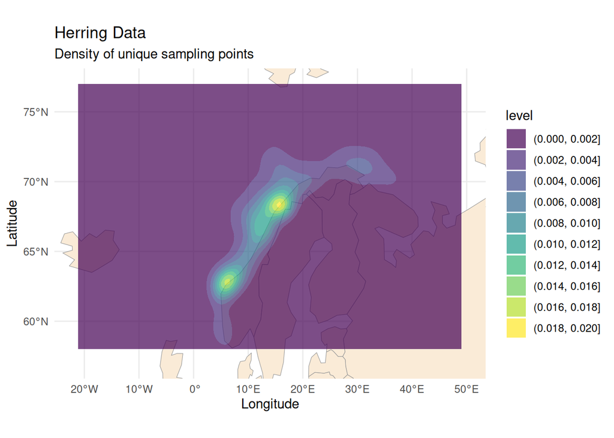

```r
herring_data_no_duplicates <- herring_data |>
  # Fjerner duplikater
  distinct(lon, lat, .keep_all = TRUE) |>
  # konvertet til sf
  st_as_sf(coords = c("lon", "lat"), crs = 4326)

# Henter ut data for plottingen
herring_coords <- cbind(
  st_coordinates(herring_data_no_duplicates),
  as.data.frame(herring_data_no_duplicates)
) |> #st_coordinates gir standard navn X og Y. Ønsker å beholde lon & lat
  rename(lon = X, lat = Y)

# Bruker Europa som bakgrunnskart
europe <- ne_countries(continent = "Europe", returnclass = "sf")

# Lager plottet
map_unique_sampling_points <- ggplot() +
  geom_sf(data = europe, fill = "antiquewhite", color = "gray60") +
  geom_density_2d_filled(
    data = herring_coords,
    aes(x = lon, y = lat),
    alpha = 0.7
  ) +
  coord_sf(xlim = c(lon_min, lon_max), ylim = c(lat_min, lat_max)) +
  theme_minimal() +
  labs(
    title = "Herring Data",
    subtitle = "Density of unique sampling points",
    x = "Longitude",
    y = "Latitude"
  )

map_unique_sampling_points
```

Dette kartet (map_catches_1935_2019) viser spredningen av individuelle sild fanget fra 1935 - 2019. I dette tidsrommet er majoriteten av sildene fanget i nord- og sør for Ålesund, samt. en økning i Vestfjorden. Totalt fangst: 410 355 individer

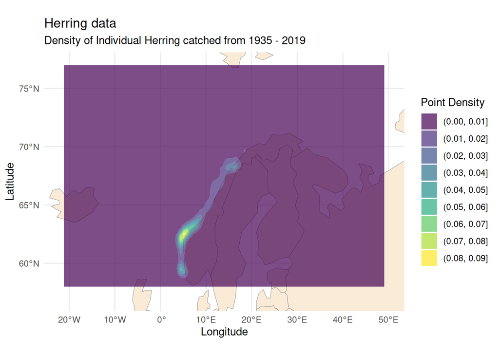

```r
herring_data <- herring_data |>
  st_as_sf(coords = c("lon", "lat"), crs = 4326)

# Bruker Europa som bakgrunnskart
europe <- ne_countries(continent = "Europe", returnclass = "sf")

# Plotter kartet med punkt størrelse 2, farget blått med transparens på 0.7
map_catches_1935_2019 <- ggplot() +
  geom_sf(data = europe, fill = "antiquewhite", color = "gray60") +
  geom_density_2d_filled(
    data = st_coordinates(herring_data) |>
    as.data.frame(),
    aes(X, Y),
    alpha = 0.7
  ) +
   coord_sf(xlim = c(lon_min, lon_max), ylim = c(lat_min, lat_max)) +
  theme_minimal() +
   labs(
    title = "Herring data",
    subtitle = "Density of Individual Herring catched from 1935 - 2019",
    x = "Longitude",
    y = "Latitude",
    fill = "Point Density"
   )
map_catches_1935_2019
```

Dette kartet (map_catches_1970_2019) viser spredningen av individuelle sild fanget fra 1970 - 2019. På lik måte som for kartet som viser fangst fra 1935 - 2019, så forekommer majoriteten av fangsten utenfor Ålesund. Det er derimot mindre fangst sør for Ålesund, og det virker som det er en trend nordover mot Vestfjoden. Total fangst: 252 314 individer

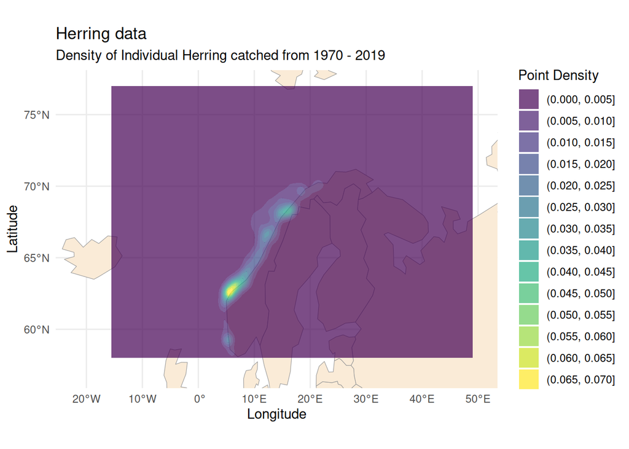

```r
herring_data <- herring_data |>
  filter(year >= 1970, year <= 2019) |>
  st_as_sf(coords = c("lon", "lat"), crs = 4326)

# Omdanner geometry kolonne til df med lat/lon
coord_df <- st_coordinates(herring_data) |>
  as.data.frame() |>
  rename(lon = X, lat = Y)

# Plotter kartet med punkt størrelse 2, farget blått med transparens på 0.7
map_catches_1970_2019 <- ggplot() +
  geom_sf(data = europe, fill = "antiquewhite", color = "gray60") +
  geom_density_2d_filled(
    data = coord_df,
    aes(x = lon, y = lat),
    alpha = 0.7
  ) +
   coord_sf(xlim = c(lon_min, lon_max), ylim = c(lat_min, lat_max)) +
  theme_minimal() +
   labs(
    title = "Herring data",
    subtitle = "Density of Individual Herring catched from 1970 - 2019",
    x = "Longitude",
    y = "Latitude",
    fill = "Point Density"
   )
map_catches_1970_2019
```

Dette kartet (map_catches_2000_2019) viser spredningen av individuelle sild fanget fra 2000 - 2019. Ser på lik måte som for 1970 - 2019 kartet at trenden fortsetter nordover, men enda tydeligere. Total fangst: 72 905 individer.

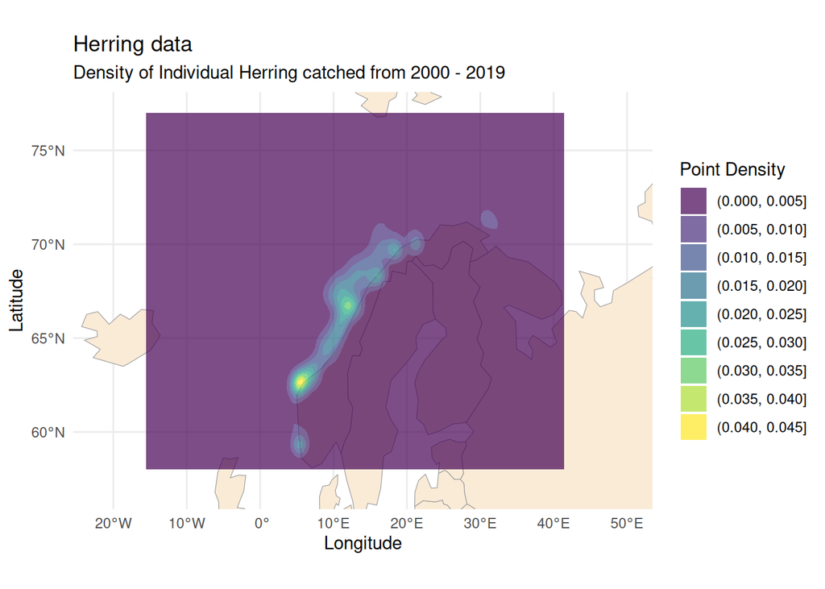

```r
herring_data <- herring_data |>
  filter(year >= 2000, year <= 2019) |>
  st_as_sf(coords = c("lon", "lat"), crs = 4326)

# Omdanner geometry kolonne til df med lat/lon
coord_df <- st_coordinates(herring_data) |>
  as.data.frame() |>
  rename(lon = X, lat = Y)

# Plotter kartet med punkt størrelse 2, farget blått med transparens på 0.7
map_catches_2000_2019 <- ggplot() +
  geom_sf(data = europe, fill = "antiquewhite", color = "gray60") +
  geom_density_2d_filled(
    data = coord_df,
    aes(x = lon, y = lat),
    alpha = 0.7
  ) +
   coord_sf(xlim = c(lon_min, lon_max), ylim = c(lat_min, lat_max)) +
  theme_minimal() +
   labs(
    title = "Herring data",
    subtitle = "Density of Individual Herring catched from 2000 - 2019",
    x = "Longitude",
    y = "Latitude",
    fill = "Point Density"
   )
map_catches_2000_2019
```

Kort oversikt over de ulike kartene laget ovenfor.

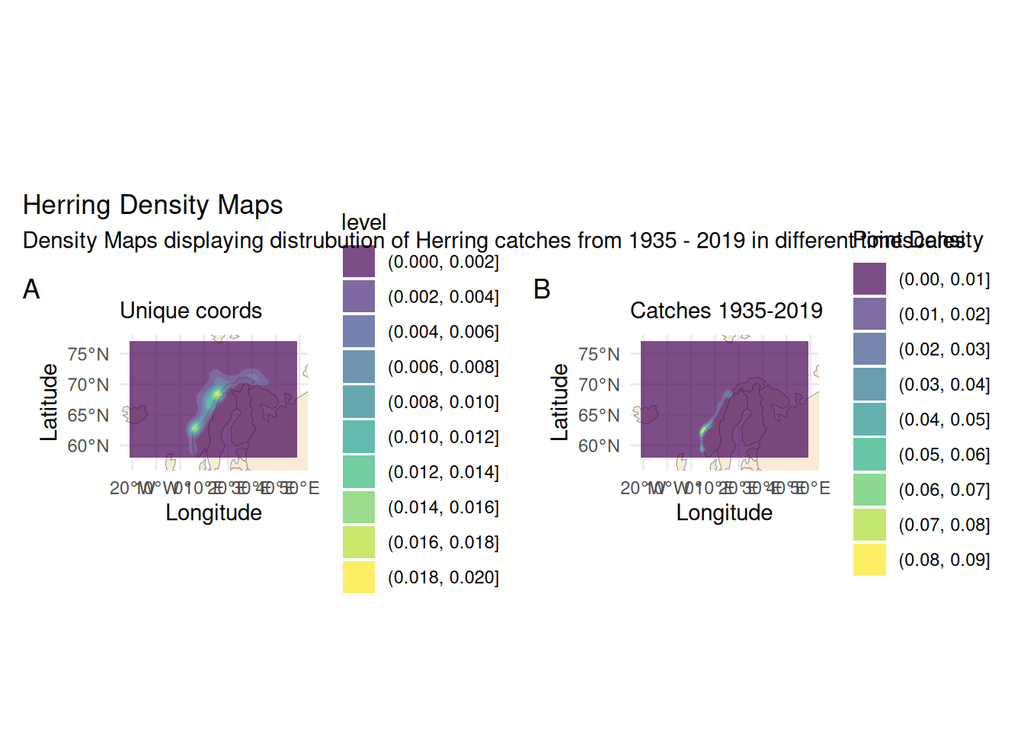

```r
#install.packages("patchwork")
library(patchwork)

map_unique_sampling_points <- map_unique_sampling_points + labs(title = NULL, subtitle = "Unique coords")
map_catches_1935_2019 <- map_catches_1935_2019 + labs(title = NULL, subtitle = "Catches 1935-2019")
map_catches_1970_2019 <- map_catches_1970_2019 + labs(title = NULL, subtitle = "Catches 1970-2019")
map_catches_2000_2019 <- map_catches_2000_2019 + labs(title = NULL, subtitle = "Catches 2000-2019")

(map_unique_sampling_points | map_catches_1935_2019) +
  plot_annotation(
    title = "Herring Density Maps",
    subtitle = "Density Maps displaying distrubution of Herring catches from 1935 - 2019 in different timescales",
    tag_levels = 'A'
  )
```

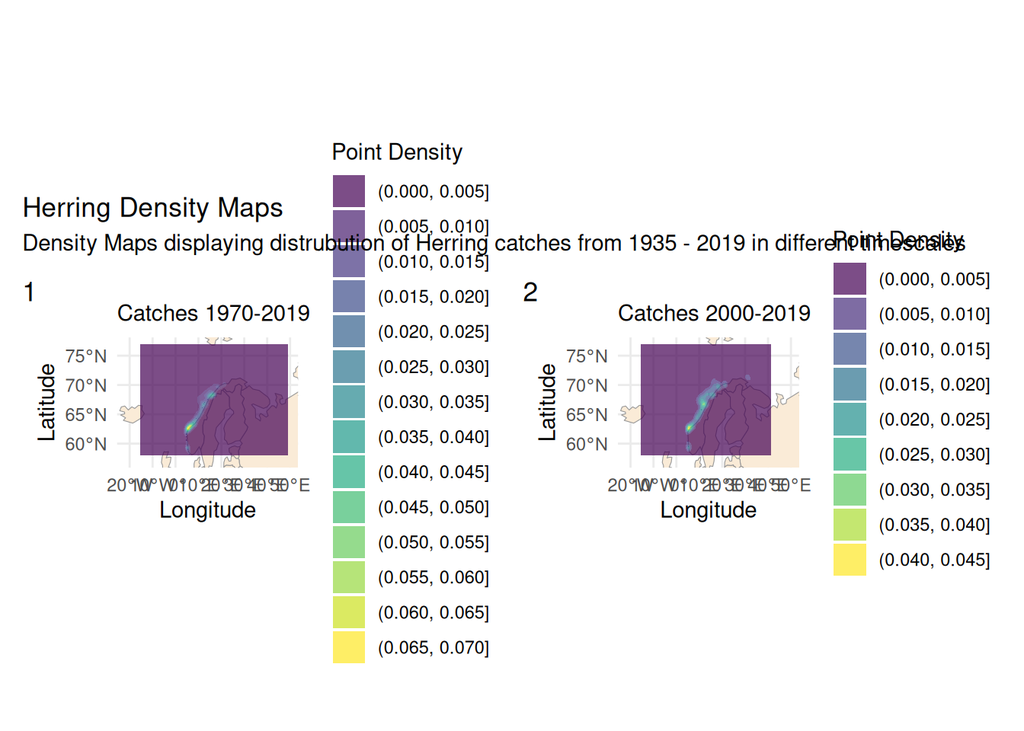

```r
(map_catches_1970_2019 | map_catches_2000_2019) +
    plot_annotation(
    title = "Herring Density Maps",
    subtitle = "Density Maps displaying distrubution of Herring catches from 1935 - 2019 in different timescales",
    tag_levels = '1'
    )
```

########################################################################

Prøver å gå vekk ifra contour plot ved å bruke “binned counts” (ingen interpolasjon).

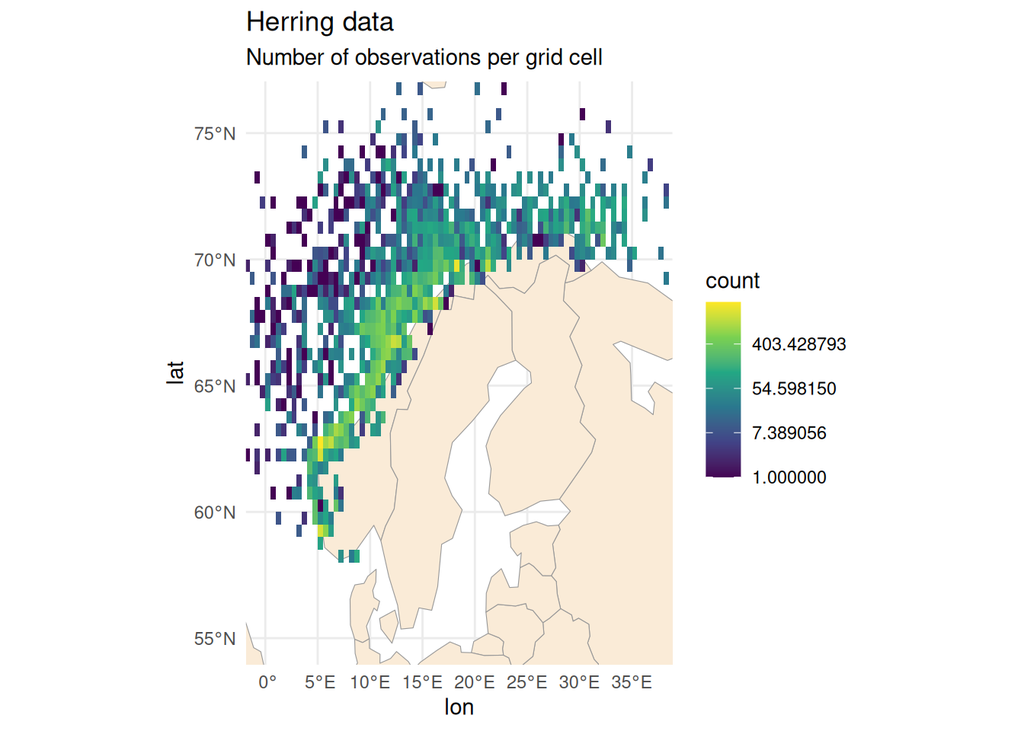

```r
herring_data <- herring_data |>
  st_as_sf(coords = c("lon", "lat"), crs = 4326)

# Omdanner geometry kolonne til df med lat/lon
coord_df <- st_coordinates(herring_data) |>
  as.data.frame() |>
  rename(lon = X, lat = Y)

ggplot() +
  geom_sf(data = europe, fill = "antiquewhite", color = "gray60") +
  geom_bin2d(
    data = coord_df,
    aes(x = lon, y = lat),
    binwidth = c(0.5, 0.5)  # 0.5° grid (~50 km)
  ) +
  scale_fill_viridis_c(trans = "log", na.value = "white") +
  coord_sf(xlim = c(0, 37), ylim = c(55, 76)) +
  theme_minimal() +
  labs(title = "Herring data", subtitle = "Number of observations per grid cell")
```

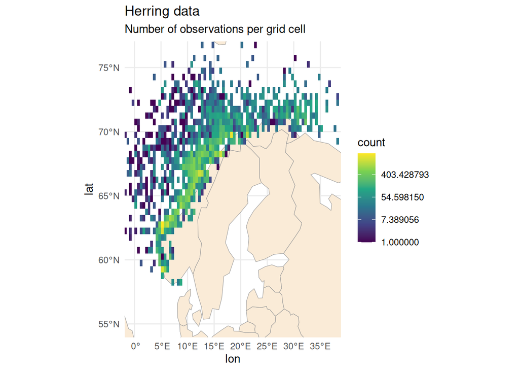

```r
herring_data <- herring_data |>
  filter(year >= 1970, year <= 2019) |>
  st_as_sf(coords = c("lon", "lat"), crs = 4326)

# Omdanner geometry kolonne til df med lat/lon
coord_df <- st_coordinates(herring_data) |>
  as.data.frame() |>
  rename(lon = X, lat = Y)

ggplot() +
  geom_sf(data = europe, fill = "antiquewhite", color = "gray60") +
  geom_bin2d(
    data = coord_df,
    aes(x = lon, y = lat),
    binwidth = c(0.5, 0.5)  # 0.5° grid (~50 km)
  ) +
  scale_fill_viridis_c(trans = "log", na.value = "white") +
  coord_sf(xlim = c(0, 37), ylim = c(55, 76)) +
  theme_minimal() +
  labs(title = "Herring data", subtitle = "Number of observations per grid cell")
```